# ECoS Greenhouse Gas Inventory 2019

### Raymond Friend, Mathematics

### June 14, 2021

## Inspiration

1. The University produces an annual GHG inventory

[figure not shown]

## Inspiration

1. First unit to perform unit-level GHG inventory: **EMS**

[figure not shown]

# Total ECoS Footprint

ECoS produced...

## 28,152 MtCO$_2$e

... of greenhouse gas emissions during 2019

That's equivalent to:

- Driving $\mathbf{6,100}$ **passenger vehicles** continuously for a year
- The carbon sequestered in $\mathbf{34,500}$ **acres of forest** over a year
  - $\approx \mathbf{50}$ Stone Valleys

# ECoS Emissions by Source

## GHG Emissions Sources

- **Utilities**
  - Steam
  - Electric
  - Chilled Water
  - Water
  - Sewer
  - Natural Gas
- **Mobile Combustion**
  - Air Travel
  - Global Programs
  - Car Travel
  - Commuting
  - ECoS Owned Vehicles
- **High Performance Computing**
- **Procurement**

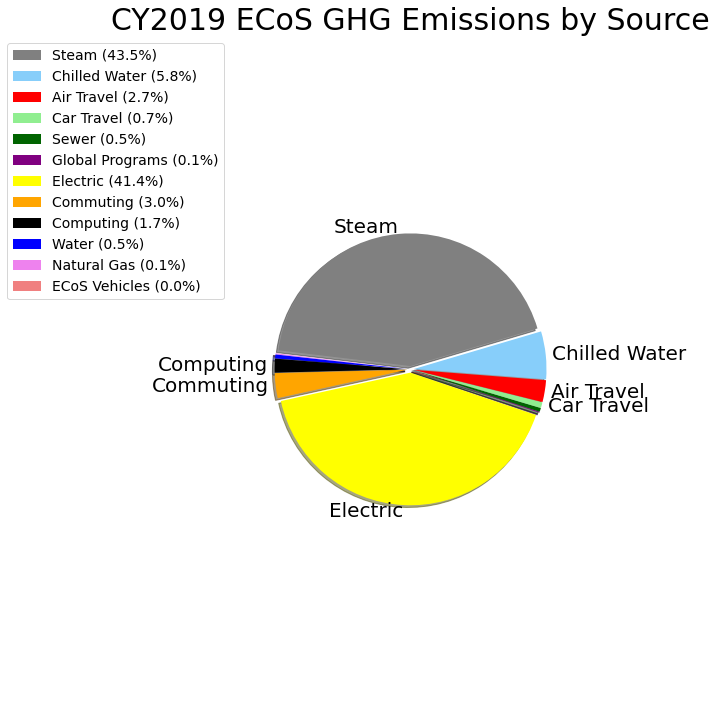

```python
from pychart import *

labels = ['Steam', 'Electric',  'Chilled Water',  'Water',  'Sewer',  'Natural Gas',  'Air Travel', 'Global Programs',  'Car Travel',  'Commuting', 'ECoS Vehicles', 'Computing']
values = [12257, 11652, 1637, 134, 129, 38, 748, 33, 197, 853, 1, 474]
colors = ['gray', 'yellow', 'lightskyblue', 'blue', 'darkgreen', 'violet', 'red', 'purple', 'lightgreen', 'orange', 'lightcoral', 'black']
title = "CY2019 ECoS GHG Emissions by Source"

create_pychart(labels, values, colors, title)
```

# ECoS Scope 3 Emissions

### **Scope 3 Emissions**:

- Indirect
- Assets not owned nor controlled by ECoS
- "Value Chain Emissions"
- "Someone else's direct emissions"

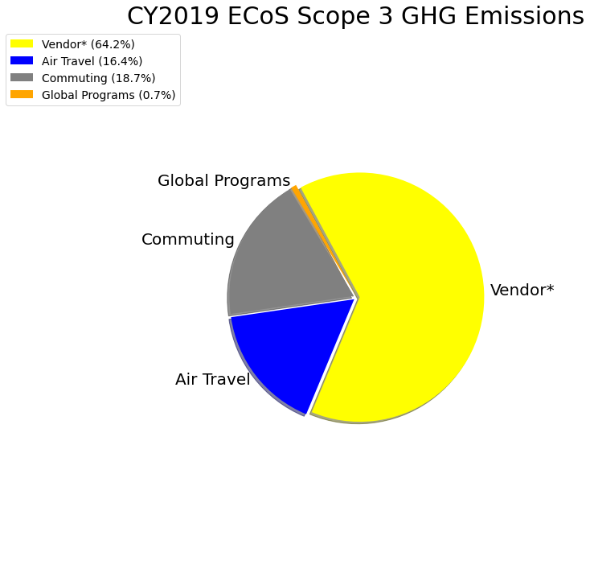

```python
from pychart import *

labels = ['Air Travel', 'Global Programs', 'Commuting', 'Vendor*']
values = [748, 33, 853, 2927]
colors = ['blue', 'orange', 'gray', 'yellow']
title = "CY2019 ECoS Scope 3 GHG Emissions"

create_pychart(labels, values, colors, title)
```

# Comparing to the University

[figure not shown]

# Utility Emissions by Building

## Emissions by Building

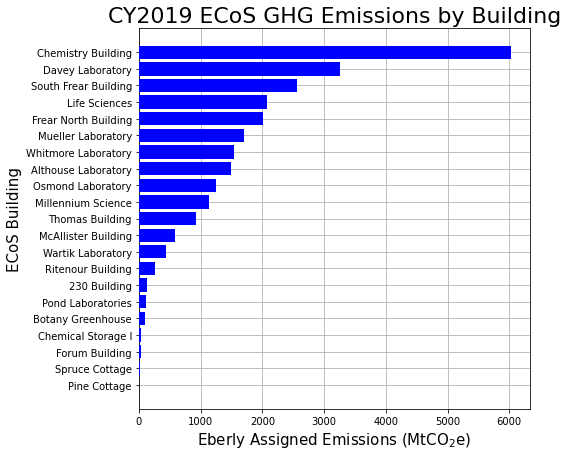

```python
from pychart import *

labels = ["Pine Cottage", "Spruce Cottage", "Forum Building", "Chemical Storage I", "Botany Greenhouse", "Pond Laboratories", "230 Building", "Ritenour Building", "Wartik Laboratory", "McAllister Building", "Thomas Building", "Millennium Science", "Osmond Laboratory", "Althouse Laboratory", "Whitmore Laboratory", "Mueller Laboratory", "Frear North Building", "Life Sciences", "South Frear Building", "Davey Laboratory", "Chemistry Building"]
values = [5, 13, 26, 37, 99, 116, 125, 266, 437, 583, 919, 1142, 1250, 1490, 1544, 1707, 2008, 2072, 2559, 3259, 6028]
y_label = "ECoS Building"
x_label = "Eberly Assigned Emissions (MtCO$_2$e)"
title = "CY2019 ECoS GHG Emissions by Building"
color = 'blue'

create_barh(labels, values, color, y_label, x_label, title)
```

## Emissions by Building, Normalized by Floor Area

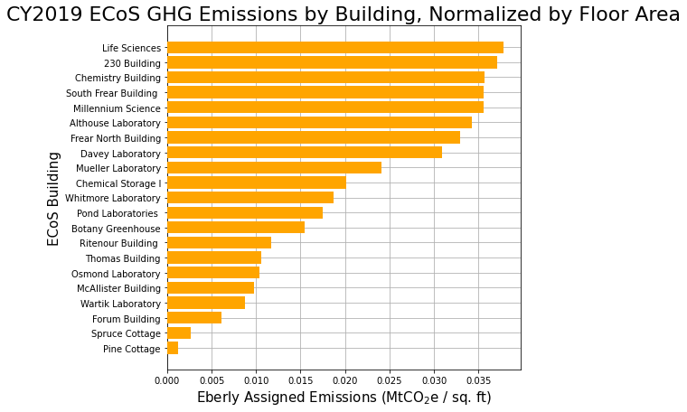

```python
from pychart import *

labels = ["Pine Cottage", "Spruce Cottage", "Forum Building", "Wartik Laboratory", "McAllister Building", "Osmond Laboratory", "Thomas Building", "Ritenour Building ", "Botany Greenhouse", "Pond Laboratories ", "Whitmore Laboratory", "Chemical Storage I", "Mueller Laboratory", "Davey Laboratory", "Frear North Building", "Althouse Laboratory", "Millennium Science", "South Frear Building ", "Chemistry Building", "230 Building", "Life Sciences"]
values = [0.001219352, 0.002611855, 0.006067759, 0.00874018822007396, 0.009780355, 0.010413761, 0.01061126, 0.011707838, 0.015480026, 0.017480376, 0.018748482, 0.020171776, 0.024055153, 0.030957909, 0.032916542, 0.034224057, 0.0355392109265944, 0.035551108, 0.035659854, 0.037122932, 0.0378102580156587]
y_label = "ECoS Building"
x_label = "Eberly Assigned Emissions (MtCO$_2$e / sq. ft)"
title = "CY2019 ECoS GHG Emissions by Building, Normalized by Floor Area"
color = 'orange'

create_barh(labels, values, color, y_label, x_label, title)
```

# Future Work

## Procedural

- Procurement
- Scope 3 Guidance
- Pandemic Comparison

## Collaboration

- Sustainable Operations Council
- Drawdown Scholars
- Improved Record Keeping

## Evaluation and Action

- Make this inventory an annual action
- Tie specific actions to the outcomes of future inventories
- Task the ECoS Sustainability Council to guide our actions

# Opportunities for Action

## Emissions Reductions

- **Utilties** comprise 91.8% of our footprint
  - Perform space evaluation & survey
  - Should expect this sector to partially reduce over time "for free"
- Scope 3 emissions are smaller, but
  - **Persist** even if UP goes fully renewable
  - Can avoid with better practices
- Sustainable Corporate Engagment
  - Decarbonize our procurement supply chain
  - Partner in drawdown **projects** (like the PPA)
- Encourage **remote/hybrid** work and events

## Emissions Offsets

*Carbon offsets*: a cheap option to offset emissions by funding carbon mitigation projects

  $$\mathbf{\$140,000-\$560,000}^*$$

  *assuming \$5-\$20 per tonne

## Green Labs

- **Purpose**: encourage sustainable literacy and operations across PSU's labs
- Labs are significantly more energy intensive than office space
- ECoS has the opportunity to pilot this program
- Kristin Dreyer (MRSEC) and Lydia Vandenbergh (SI)
- All are welcome to join the meeting tomorrow at 1:00PM

## Sustainable Corporate Engagement

- ECoS spent over \$11,000,000 on supplies and equipment in 2019
- Suppliers have only just started evaluating their environmental and social impacts
- ECoS should **request sustainability snapshots** from its top vendors
- ECoS should strategically **build relationships with suppliers**

## Advocacy at the University Level

- We have varying levels of **control** over our emissions
- Univeristy has greater control over emissions factors (Scopes 1 & 2)
- ECoS **cannot wait** for the University to act
- The University acts when it is held accountable

## Education and Leadership

- Student-led initiatives calling for **sustainable education**
- ECoS Sustainability Council mapped SDGs to course syllabi
- Need **guidance** for incorporating sustainability into courses
- Assist other units and institutions with performing their own sustainability snapshots

# ECoS Emissions by Scope

## GHG Emissions Scopes

- **Scope 1**
  - Direct
  - Burning onsite
  - E.g., Steam, Natural Gas, Reimbursed Car Travel
- **Scope 2**
  - Indirect
  - Purchased utilities
  - E.g., Purchased Electricity, Chilled Water
- **Scope 3**
  - Indirect
  - Everything else
  - E.g., Air Travel, Commuting, Vendor Emissions

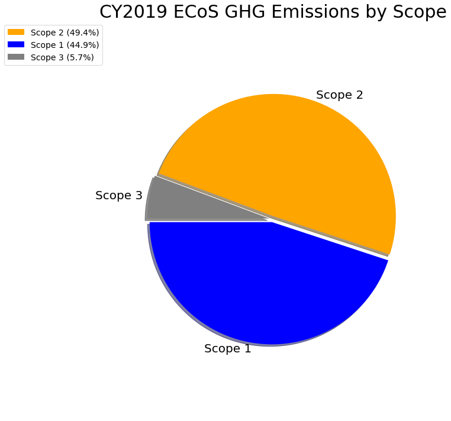

```python
from pychart import *

labels = ['Scope 1', 'Scope 2', 'Scope 3']
values = [12636, 13882, 1601]
colors = ['blue', 'orange','gray']
title = "CY2019 ECoS GHG Emissions by Scope"

create_pychart(labels, values, colors, title)
```